# R Notebook : Analyse des résidus - Rappels de cours

Les résidus d’une régression sont souvent notés $\varepsilon_t$ par convention. Ils représentent l’écart entre la variable dépendante de la régression et ses valeurs prédites par le modèles :
$$\begin{align}
&y_t = a_0 + \beta x_t + \varepsilon_t \\
&\varepsilon_t = y_t - \hat y_t
\end{align}$$

Et les résidus représentent réellement à quel point notre modèle est précis dans son estimation. Le modèle de régression est censé représenter correctement la dynamique de la variable dépendante $y_t$ en fonction de la dynamique d’autres variables ($x_t$), du temps (avec une trend, un cycle, une saisonnalité, etc… si on observe leur présence) et de la structure propre de la série (ARIMA). Cependant, on n’est pas censé représenter la variable dépendante avec une précision parfaite : le modèle peut sur-estimer ou sous-estimer de temps en temps la dynamique.

Cependant, quand on fait le modèle de régression, on part du principe que, si il est correct, on va correctement estimer la dynamique dans l’ensemble. On peut sur-estimer ou sous-estimer, mais en moyenne il faut que ces erreurs soient le plus proche possible de 0 : **la moyenne des résidus doit donc être proche de 0**. Egalement, on veut se tromper autant dans la sur-estimation que dans la sous-estimation (on ne veut pas sous-estimer la variable en permanence) : **la somme des résidus doit être proche de 0**. Egalement, on veut se tromper du même ordre peu importe la période : **la moyenne et la variance des résidus doivent être constants.** De cette condition découle une autre : **les résidus doivent être indépendants.** Autrement dit, **le coefficient d’autocorrélation des résidus doit être nul** (si on se trompe à une période, ça ne veut pas dire qu’on va se tromper à la période suivante) et ne doivent pas dépendre de $Y_t$ (le coefficient de régression entre $\varepsilon_t$ et $Y_t$ doit être nul). Au final, **les résidus doivent donc suivre une loi normale, centrée autour de zéro.**

Si on résume ces cas :
$$\begin{align}
& \mathbb{E}(\varepsilon) = 0 \quad \text{esperance (moyenne) nulle
du terme d'erreur}\\
& \sum_{i=1}^N\varepsilon_i = 0 \quad \text{somme nulle des erreurs}
\\
& \mathbb{E}(\varepsilon)=\mathbb{E}(\varepsilon_{t+h}) \quad
\text{moyenne constante} \\
& \operatorname{Var}(\varepsilon) = \sigma^2_\varepsilon \quad
\text{homoscedasticite} \\
& \operatorname{Cov}(\varepsilon_t, \varepsilon_{t-h})=0
\quad \text{independence des erreurs} \\
& \operatorname{Cov}(\varepsilon_t, Y_{t})=0 \quad \text{exogeneite}
\\
& \rightarrow\varepsilon_t \overset{\text{i.i.d.}}{\sim} \mathcal
N(0,\sigma_\varepsilon^2) \quad \text{erreurs suivent une loi normale}
\end{align}$$

*Note : $i.i.d$ signifie identiquement et indépendamment distribués*. Ces cas sont nombreux, mais au final on retombe assez vite sur ce qu’on a vu dans la séance sur la stationnarisation (séance 3) : on veut obtenir une suite de bruits blancs.

En effet, il faut imaginer que les séries temporelles ne sont qu’une suite de bruits blancs, et que ces bruits blancs sont impactés par des chocs exogènes (qui proviennent d’autres variables). Avec la régression, on retire l’influence de ces variables exogènes, et on est censé retomber sur la suite de bruits blancs originelle.

Pour s’assurer que l’estimateur de smoindres carrés permette de remplir les conditions concernant les erreurs, plusieurs hypothèses doivent donc être vérifiées:

- Linéarité du modèle
- Espérance nulle du terme d’erreur
- Homoscédasticité
- Absence d’autocorrélation
- Exogénéité des variables explicatives

## 5a - L’hypothèse de linéarité

La première hypothèse du modèle de régression linéaire concerne la linéarité du modèle. Pour bien comprendre, on avait dit précédemment que l’équation de régression
$$y_t = \beta_0 + \beta x_t + \varepsilon_t$$
est l’équivalent d’une fonction affine (si on néglige le terme d’erreur qui est une construction purement statistique) :
$$y = ax + b$$
où la constante $b$ correspond à $\beta_0$ et où la pente $a$ est décrite par le coefficient de régression $\beta$.

Lorsqu’on modélise la relation entre `y` et `x`, on pose implicitement l’hypothèse qu’elle est linéaire : quand `x` augmente d’une unité, ça fait varier `y` d’une quantité $\beta$. Pour l’exemple des distances de freinage en fonction de la vitesse, un peu plus haut, cette hypothèse était relativement bien vérifiée : la droite de régression colle relativement bien aux points d’observations.

En revanche, pour certaines relations, on peut observer de la non-linéarité dans la relation qui les lie. Par exemple, quand on chauffe un liquide (comme du mercure par exemple), certaines molécules vont se transformer à l’état gazeux, ce qui créé une augmentation de la pression.

La physique montre que la pression de vapeur d’un liquide suit une relation exponentielle avec la température : la pression augmente donc de plus en plus rapidement lorsque la température augmente. Appliquer un modèle de régression **linéaire** n’est donc pas forcément approprié :

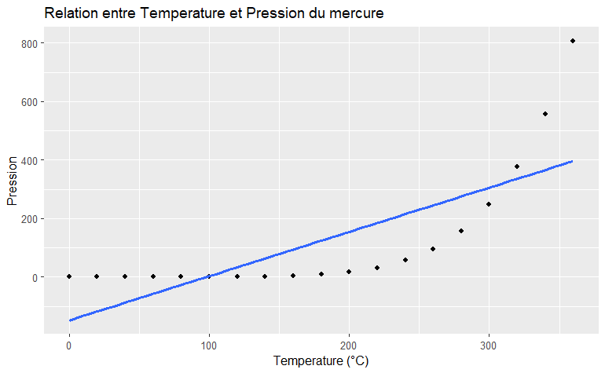

Ici, on voit bien que la droite de régression n’arrive à prédire correctement la pression induite par la température qu’en deux points : lorsque la température est de 100°C, et lorsqu’elle est environ vers 300°C. Pourtant, si on regarde seulement le résultat dans le tableau de régression :

```
                   reg_temp_press
Dependent Var.:          pressure

Constant          -147.9* (66.55)
temperature     1.512*** (0.3158)
_______________ _________________
S.E. type                     IID
Observations                   19
R2                        0.57425
Adj. R2                   0.54921
---
Signif. codes: 0 '***' 0.001 '**' 0.01 '*' 0.05 '.' 0.1 ' ' 1
```

Il semble bien que le modèle de régression arrive à capter l’effet positif de la température sur la pression. Cependant, on n’arrive pas à clairement capter la non-linéarité.

Comment régler le problème de non-linéarité ?

Deux moyens existent pour résoudre le problème de non-linéarité. Le premier est de garder un modèle linéaire, mais en transformant les variables pour que la relation devienne linéaire. Par exemple, l’inverse d’une fonction exponentielle est la fonction logarithmique. Donc, on peut essayer de mesurer l’impact de `temperature` sur le log de `pressure` avec le modèle suivant :
$$\log(pressure) = \beta_0 + \beta_1 temperature+\varepsilon$$

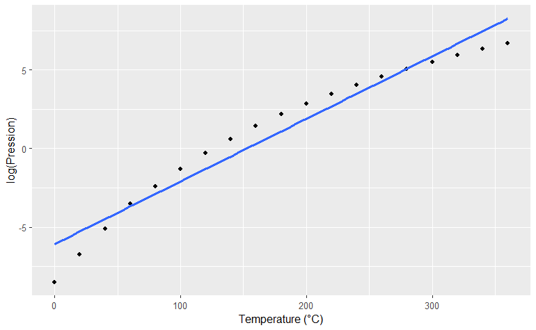

Ici, la transformation logarithmique permet d’améliorer l’estimation, est de respecter davantage l’hypothèse de linéarité de la relation entre `pressure` et `temperature`.

```
                           reg_log
Dependent Var.:      log(pressure)

Constant        -6.068*** (0.4838)
temperature     0.0398*** (0.0023)
_______________ __________________
S.E. type                      IID
Observations                    19
R2                         0.94643
Adj. R2                    0.94328
---
Signif. codes: 0 '***' 0.001 '**' 0.01 '*' 0.05 '.' 0.1 ' ' 1
```

Le deuxième moyen est d’utiliser un modèle non-linéaire. Dans ce cas, il suffit simplement d’ajouter un terme quadratique (un terme élevé au carré). Ici, on pourrait alors estimer l’équation suivante :
$$pressure = \beta_0 + \beta_1 temperature + \beta_2 temperature^2 +
\varepsilon$$

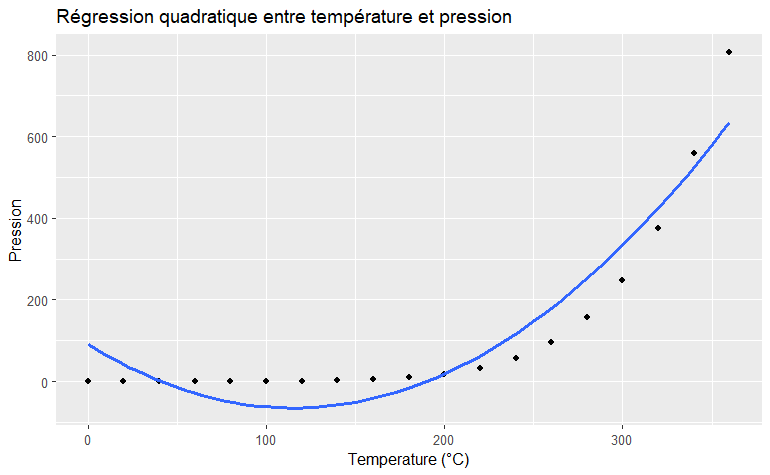

Ici, le modèle est dit non-linéaire car la droite de régression n’est pas une droite, elle suit une fonction non-linéaire.

```
                           reg_quadra
Dependent Var.:              pressure

Constant               91.15. (46.26)
temperature        -2.706*** (0.5958)
temperature square 0.0117*** (0.0016)
__________________ __________________
S.E. type                         IID
Observations                       19
R2                            0.90244
Adj. R2                       0.89024
---
Signif. codes: 0 '***' 0.001 '**' 0.01 '*' 0.05 '.' 0.1 ' ' 1
```

Ici, le terme quadratique est positif, ce qui signifie que plus la température augmente, plus l’effet sur la pression est fort. Le terme non-quadratique quant à lui est négatif. Cela est lié au fait que la pente change d’orientation, à peu près vers 115°C. Cela reste une approximation, car notre modèle ici montre qu’à faible température, une augmentation de la température réduit la pression. Ce n’est pas le cas en réalité.

Dans ces cas là, la théorie est importante (en physique comme en économie d’ailleurs). L’équation théorique de la relation entre pression est température est donnée par l’équation de Clausius-Clapeyron qui, pour simplifier, peut être écriture de la forme suivante :
$$\log(pressure) = \alpha - \frac{\beta}{T_t}$$
où $T_t$ est la température en Kelvin. Quand on applique cette équation aux données :

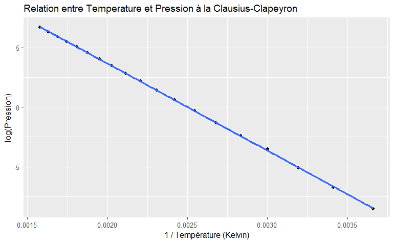

On observe bien que les valeurs prédites collent aux vraies observations.

## 5b - L’hypothèse d’espérance nulle du terme d’erreur

Une autre hypothèse importante du modèle de régression linéaire concerne le terme d’erreur $\varepsilon_t$. On considère généralement que ce terme à une espérance (une moyenne) nulle :
$$E(\varepsilon_t)=0$$
Cette hypothèse signifie qu’en moyenne, les facteurs non observés regroupés dans $\varepsilon_t$ ne poussent pas systématiquement la variable $y_t$ vers le haut ou vers le bas.

Dans un modèle simple comme celui donné plus haut

$$y_t = \beta_0 + \beta x_t + \varepsilon_t$$

L’hypothèse $E(\varepsilon_t)=0$ signifie que la partie non expliquée par $x_t$ est, en moyenne, nulle.

Une autre interprétation de l’espérance nulle du terme d’erreur est de se dire que l’on pose l’hypothèse qu’on peut se tromper, quand on estime le modèle expliquant la dynamique de $y_t$ (ce que fait le modèle de régression : il estime la dynamique de $y_t$ en fonction des variables qui l’expliquent). Cependant, il faut qu’on se trompe autant dans le positif, que dans le négatif. En moyenne, les écarts positifs et négatifs autour de la droite de régression se compensent.

Si on reprend l’exemple de la relation entre vitesse d’une voiture et distance de freinage. Même si la vitesse explique une partie de la distance de freinage, d’autres facteurs interviennent également : l’état de la route, le poids du véhicule, l’usure des pneus, le temps de réaction du conducteur, etc.

Tous ces facteurs non observés sont regroupés dans $\varepsilon_t$. Dire que $E(\varepsilon_t)=0$ revient à dire que, sur l’ensemble des observations, ces facteurs non observés ne conduisent pas systématiquement à sous-estimer ou surestimer la distance de freinage.

Graphiquement, cela signifie que les points doivent être répartis autour de la droite de régression, et non principalement d’un seul côté.

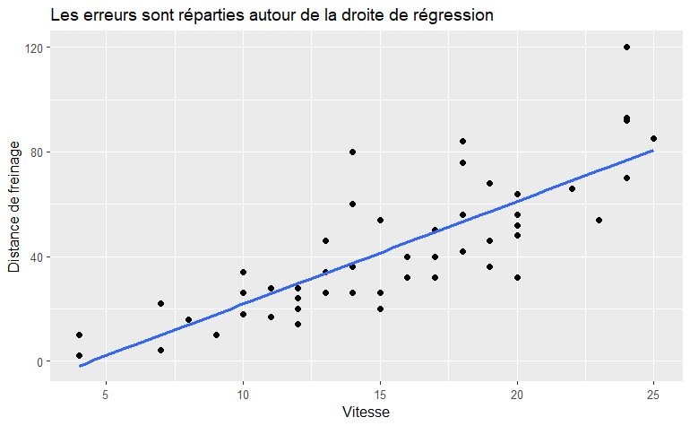

Pourquoi c’est important ?

Imaginons que la variable $y_t$ depend de deux autres variables, $x_t$ et $z_t$ : $y_t = f(x_t, z_t)$. La vraie dynamique de $y_t$ est alors déterminé par l’équation suivante :
$$y_t = \beta_0 + \beta_1 x_t +\beta_2 z_t + \varepsilon_t$$

Supposons qu’on oublie la variable $z_t$ dans la régression. On estime alors
$$y_t = \beta_0 + \beta_1 x_t + u_t$$
Ici, $u_t$ sera alors composé des erreurs **et** de $z_t$ :
$$u_t =
\beta_2 z_t + \varepsilon_t$$
Dans ce cas, l’erreur ne représente plus seulement un bruit aléatoire, mais aussi une partie structurée de la réalité économique. Le modèle risque alors d’être mal spécifié en raison d’un **biais de variable omise**.

## 5c - L’hypothèse d’homoscédasticité des erreurs

Une autre hypothèse importante du modèle de régression linéaire concerne la variance des erreurs. On suppose généralement que la variance du terme d’erreur est constante :
$$Var(\varepsilon_t) = \sigma^2$$

Ici, la variance des erreurs est notée $\sigma^2$, qui ne **dépend pas du temps** : elle est constante dans le temps. Cela signifie que l’amplitude des erreurs est la même pour toutes les observations.

Autrement dit, les écarts entre les observations et la droite de régression ne doivent pas systématiquement augmenter ou diminuer avec la valeur de la variable explicative.

Lorsque cette hypothèse est respectée, on parle d’**homoscédasticité.**

En reprenant l’exemple de la relation entre distance de freinage et vitesse, on peut représenter graphiquement les résidus du modèle.

Comme précisé précédemment, les résidus correspondent à la différence entre les valeurs observées et les valeurs prédites par le modèles :

$$\varepsilon_t = y_t - \hat y_t$$

On peut alors représenter les résidus en fonction des valeurs prédites pour le cas de la relation distance de freinage - vitesse :

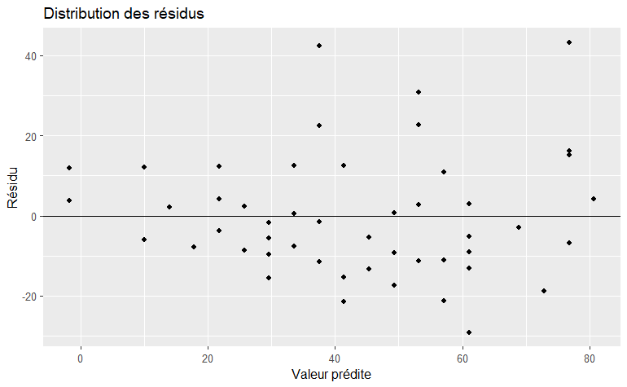

Si l’hypothèse d’homoscédasticité est respectée, les résidus doivent former un nuage de points relativement homogène autour de zéro. Autrement dit, les résidus doivent être réparits de manière aléatoire, et leur dispersion doit être à peu près constante pour toutes les valeurs prédites.

Dans le cas contraire, certains motifs (comme une forme d’éventail, où la dispersion augmente avec la valeur prédite) peuvent indiquer une violation de l’hypothèse d’homoscédasticité.

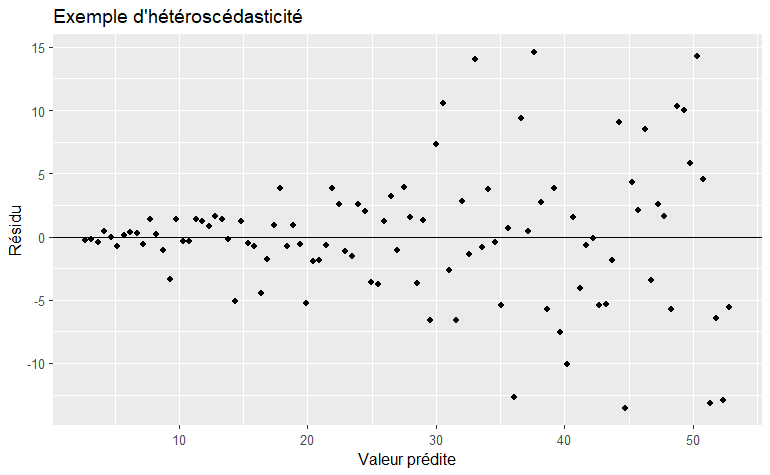

C’est le cas de certaines données, notamment financières. Les économètres utilisent alors des modèles spécifiques pour analyser cette dynamique de la variance, appelés modèles ARCH et GARCH.

## 5d - L’hypothèse d’absence d’autocorrélation des erreurs

Une autre hypothèse importante du modèle de régression concerne la corrélation entre les erreurs.

Dans le modèle de régression linéaire classique, on suppose que les erreurs sont indépendantes les unes des autres.

Mathématiquement, cela signifie que :
$$Cov(\varepsilon_t, \varepsilon_{t-h})=0$$
La covariance (ou corrélation qui est assez proche sous certaines conditions) entre les résidus en $t$ et les résidus à une période passée doit être nulle : l’erreur associée à une observation ne doit pas dépendre des erreurs passées.

Cette hypothèse signifie que les erreurs doivent se comporter comme un bruit aléatoire.

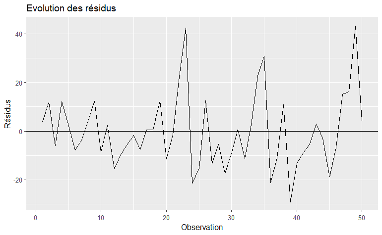

Ici, il ne semble pas y avoir d’autocorrélation entre les résidus. Le fait de se tromper positivement à une observation donnée n’induit pas systématiquement que l’on va se tromper positivement à l’observation suivante.

Il est possible de détecter formellement ce phénomène en observant la **fonction d’autocorrélation**. Dans le cas des résidus du modèle appliqué à la relation entre la distance de freinage et la vitesse, la fonction d’autocorrélation ressemble à :

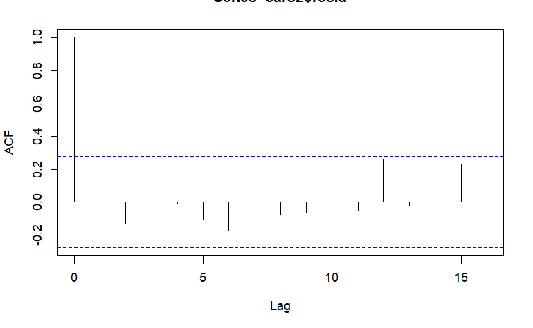

Si les erreurs sont indépendantes, toutes les corrélations doivent être proches de zéro (ou, du moins, à l’intérieur de l’intervalle de confiance en pointillés). Ici, c’est bien le cas.

*NB : la première barre est significative et affiche un coefficient d’autocorrélation de 1. C’est normal : cela correspond à l’influence de la série avec aucun lag sur la série, donc le coefficient est nécessairement de 1 : c’est l’influence de $y_t$ sur $y_t$.*

Dans certains cas, les erreurs peuvent être corrélées dans le temps.

Cela signifie qu’une erreur positive aujourd’hui augmente la probabilité d’observer une erreur positive dans la période suivante.

On parle alors **d’autocorrélation** des erreurs.

Graphiquement, cela se traduit par des périodes où les résidus restent longtemps positifs ou négatifs.

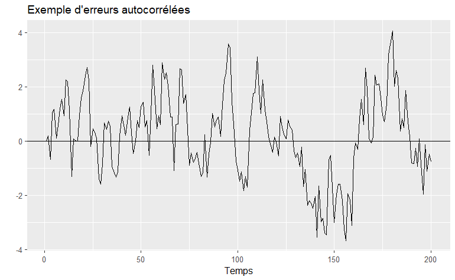

On observe que les valeurs positives et négatives ont tendance à persister dans le temps.

Dans les données économiques, l’autocorrélation est extrêmement fréquente.

Par exemple :

- le PIB dépend fortement du PIB de l’année précédente,
- l’inflation dépend souvent de l’inflation passée,
- les prix financiers dépendent des prix précédents.

La présence d’autocorrélation dans les données temporelles explique pourquoi les économètres ont développé des modèles capables de représenter explicitement la dépendance entre les observations. Ces modèles sont appelés modèles autorégressifs.

## 5e - L’hypothèse d’exogénéité des variables explicatives

Une hypothèse fondamentale du modèle de régression concerne la relation entre les variables explicatives et le terme d’erreur.

Dans le modèle de régression linéaire :

$$y_t = \beta_0 + \beta x_t + \varepsilon_t$$

On suppose que la variable explicative $x_t$ est indépendente du terme d’erreur :

$$Cov(\varepsilon_t | x_t)=0$$

Autrement dit, la variable explicative ne doit pas être corrélée avec les facteurs non observés qui affectent la variable expliquée.

L’intuition est la suivante : Le terme d’erreur $\varepsilon_t$ regroupe toutes les influences sur $y_t$ qui ne sont pas incluses dans le modèle.

Par exemple, si l’on cherche à expliquer le salaire d’un individu par son niveau d’éducation :

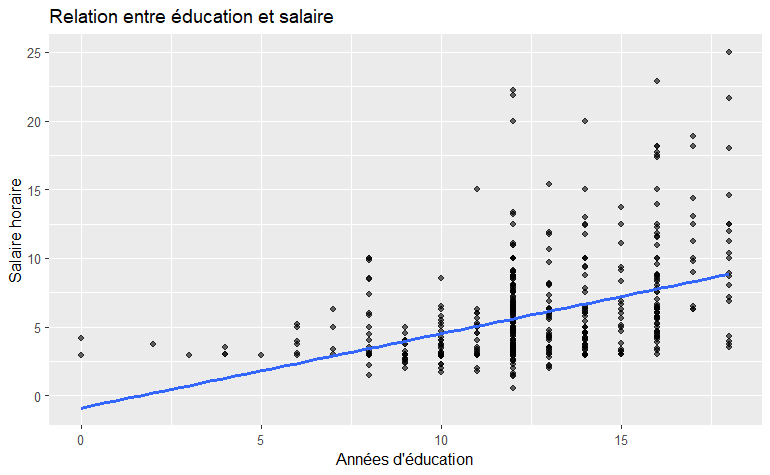

En cohérence avec ce qui est attendu, un niveau d’éducation plus élevé est associéà un salaire plus élevé. Cependant, cette relation peut être biaisée. En effet, le terme d’erreur peut inclure :

- la motivation ;
- le milieu social ;
- les compétences non observées ;
- le réseau professionnel ;
- l’expérience.

Dans ce cas, la variable d’éducation risque d’être corrélée avec le terme d’erreur si elle est liée à ces facteurs non-observés, ce qui viole l’hypothèse d’exogénéité.

Il y a cependant un piège important : avec une régression OLS, on ne peut pas “tester l’exogénéité” en regardant simplement la corrélation entre les résidus estimés et les variables explicatives du modèle. L’hypothèse porte sur la vraie erreur, non observée, pas celle estimée. L’exogénéité est une **propriété théorique**.

On a alors recours à un autre moyen pour détecter l’endogénéité des residus (la violation de l’hypothèse d’exogénéité) : d’un côté, l’intuition économique (l’éducation peut être lié à des facteurs inobservés qui rentrent dans le terme d’erreur) et de l’autre côté, l’utilisation d’un modèle enrichi.

Par exemple, on peut regarder basiquement l’influence de l’éducation sur les salaires, avec une régression linéaire univariée :
$$salaire = \beta_0 + \beta_1 education + \varepsilon_t$$

```
                              reg1
Dependent Var.:               wage

Constant          -0.9049 (0.6850)
educ            0.5414*** (0.0532)
_______________ __________________
S.E. type                      IID
Observations                   526
R2                         0.16476
Adj. R2                    0.16316
---
Signif. codes: 0 '***' 0.001 '**' 0.01 '*' 0.05 '.' 0.1 ' ' 1
```

On peut voir que l’augmentation d’une année d’étude tend à augmenter le salaire horaire de 0.54$.

Si le coefficient de `educ` change lorsqu’on ajoute d’autres variables pertinentes, cela suggère que la relation initiale captait aussi d’autres effets.

```
                              reg2
Dependent Var.:               wage

Constant        -2.873*** (0.7290)
educ            0.5990*** (0.0513)
exper             0.0223. (0.0121)
tenure          0.1693*** (0.0216)
_______________ __________________
S.E. type                      IID
Observations                   526
R2                         0.30642
Adj. R2                    0.30244
---
Signif. codes: 0 '***' 0.001 '**' 0.01 '*' 0.05 '.' 0.1 ' ' 1
```

Ici, en l’occurence, le coefficient associé à `educ` ne change pas substantiellement : une augmentation d’une année d’étude augmente le salaire horaire d’environ 0.6$.

En revanche, on a augmenté la profondeur des résultats, en utilisant des variables de contrôle. Ici, l’augmentation du salaire lié à l’augmentation du nombre d’années d’étude est garanti en gardant le nombre d’années d’expérience (`exper`) et le nombre d’années avec l’employeur actuel (`tenure`) constants.

Attention : ce n’est pas un test formel d’exogénéité, mais un indice qu’une variable omise pouvait biaiser l’estimation.